# Stepping Stones: Team 2

## Infant Health

### Mothers With Access to Prenatal Care in Virginia

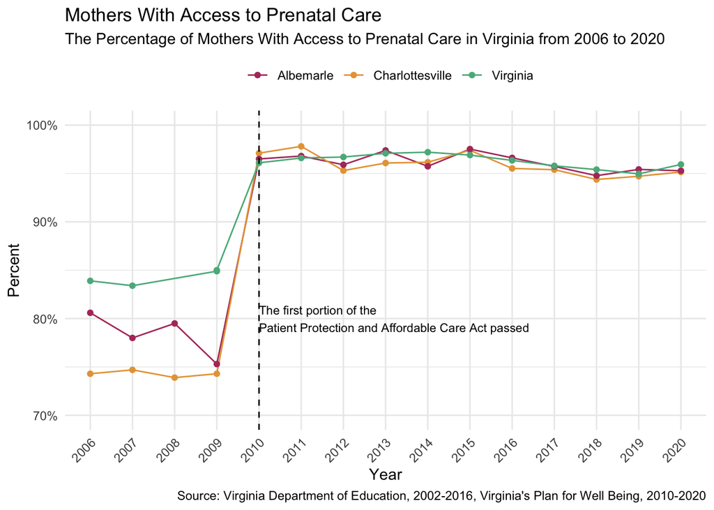

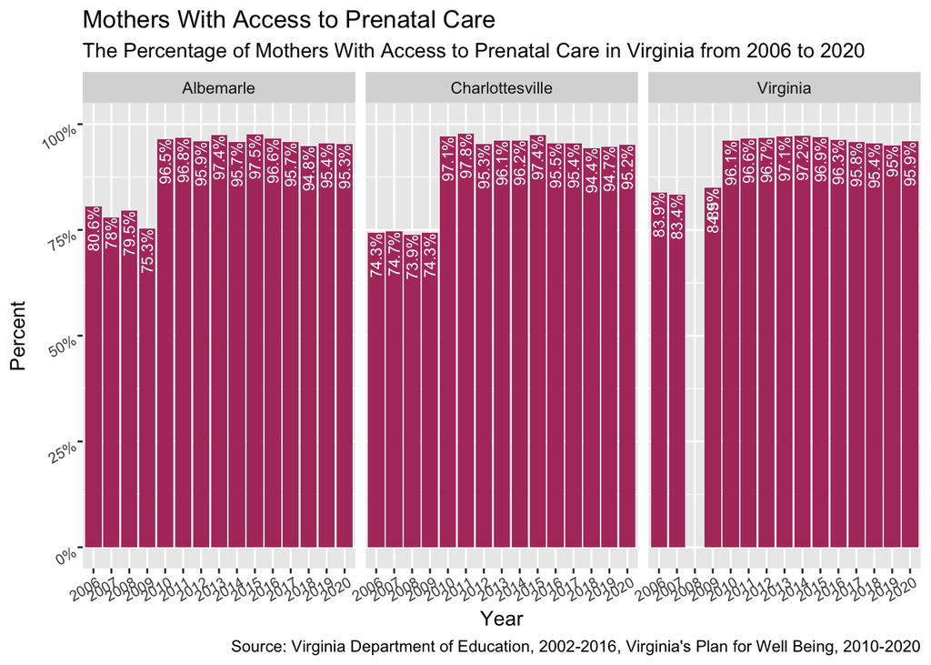

### About

Prenatal care is the health care that individuals receive while pregnant allowing those who are pregnant to take care of themselves and their babies best.

- *Why is this important:* Increasing the number of individuals who receive prenatal care may be costly. However, the initiative in the long-term could be cost-effective by preventing more severe health issues during pregnancies. Research has demonstrated that prenatal care dramatically reduces the negative effect of substances during pregnancy, including decreasing the risks of low birth weight and prematurity Substance Abuse Reporting and Pregnancy: The Role of the Obstetrician
- *How we measure this:* This is measured in the percentage mothers who received prenatal care based on the percentage of live births.
- *Further Consideration:* Increasing the number of individuals who receive prenatal care may be costly. However, the initiative in the long-term could be cost-effective by preventing more severe health issues during pregnancies. Research has demonstrated that prenatal care dramatically reduces the negative effect of substances during pregnancy, including decreasing the risks of low birth weight and prematurity. Substance Abuse Reporting and Pregnancy: The Role of the Obstetrician
- *Trends:* After the passage of the Affordable Care Act (ACE), the rate of uninsured new mothers decreased by forty-one percent nationally. The ACE also improved the quality of coverage of prenatal care by requiring coverage for maternity and newborn care, securing over 13 million people with maternity services. [Building on the ACA: Administrative Actions to Improve Maternal Health](https://www.americanprogress.org/article/building-aca-administrative-actions-improve-maternal-health/) However, prenatal care is still a major issue within the state, “several dozen Virginia counties have been designated as maternity care deserts due to the lack of essential serves,” states Carol Sakala the director for maternal health at the National Partnership for Women and Families. A top complaint among at-risk communities across the state is a lack of coordinated care and trained professionals. Data reveals that from 2018 to 2020, Virginia’s maternal mortality rate has doubled. In 2018 there was 37.1 death per 100,00 cases within a year of pregnancy; now, there is 86.6 death per 100,000 cases.[As maternal mortality rates rise in Virginia, health officials launch interviews into deaths, 2022](https://www.virginiamercury.com/2022/09/27/as-maternal-mortality-rates-rise-in-virginia-health-officials-launch-interviews-into-deaths/)
- *Who is this data about:* Pregnant individuals with or without the ability to access prenatal care. The Hear Her public campaign, conducted by the CDC, has in-depth interviews with mothers describing their experience navigating medical systems and discussing what prenatal care they received or wish they received. One such mother interviewed, named Allyson Felix, described the importance of receiving prenatal care. Allyson was diagnosed at 32 weeks pregnant with a rare and life-threatening pregnancy complication called severe preeclampsia. In her interview, she emphasizes that reproductive risks related to pregnancy can be scary and that, in her case, access to care saved her life. [Allyson Felix’s Story](https://www.cdc.gov/hearher/allysonfelix/index.html)
- *Data Source:* The Virginia Department of Health, “Maternal & Child Health”, 2006-2017,https://www.vdh.virginia.gov/data/maternal-child-health/. “Virginia Health Plan”, 2010-2020, https://virginiawellbeing.com/virginia-community-health-improvement-data-portal/vdh-assessment/

## Education

### English SOL Pass Rate-Grade 3

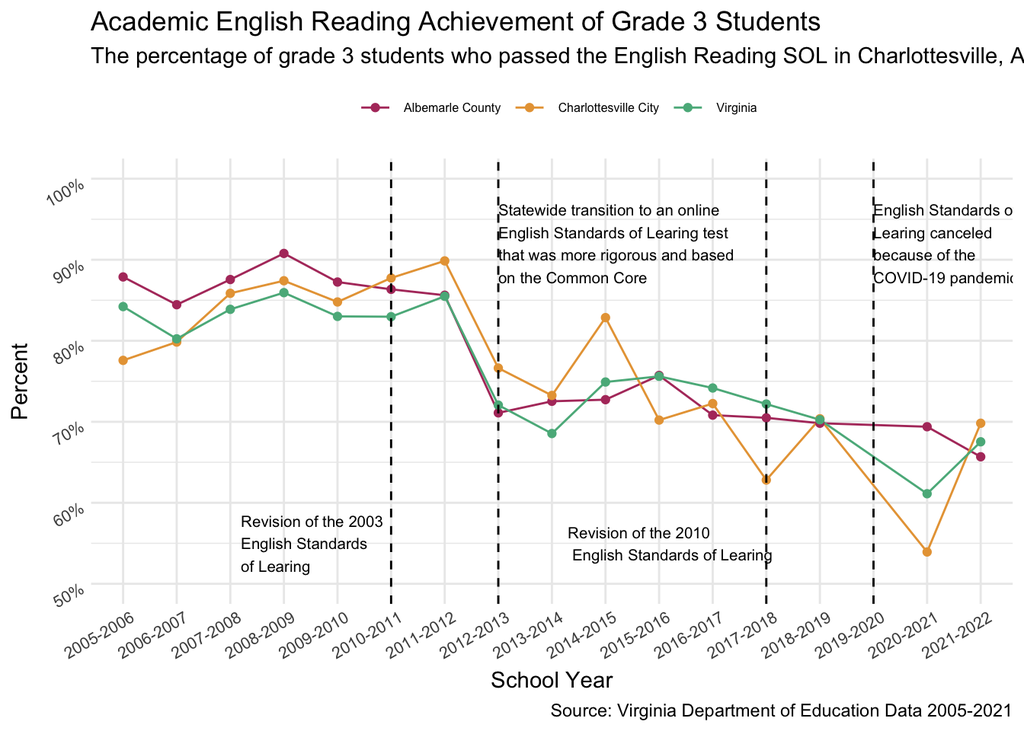

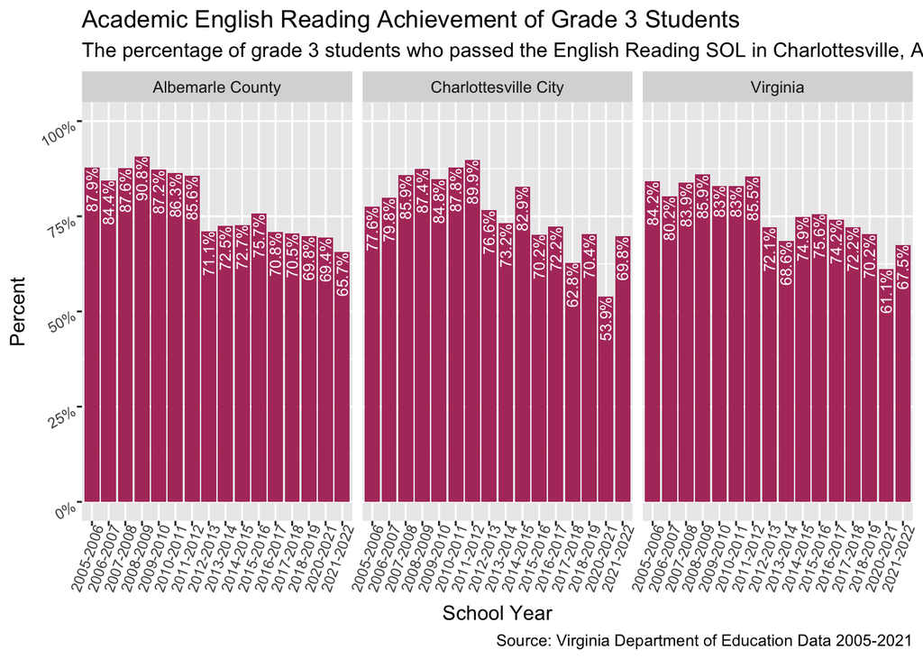

### English SOL Pass Rate-Grade 5

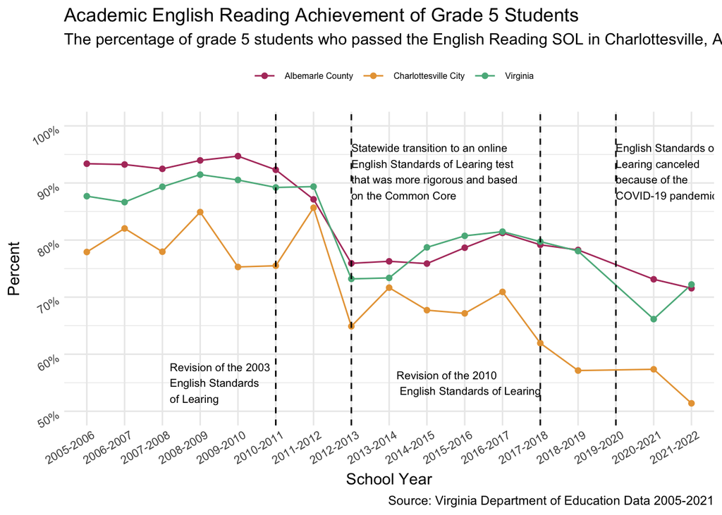

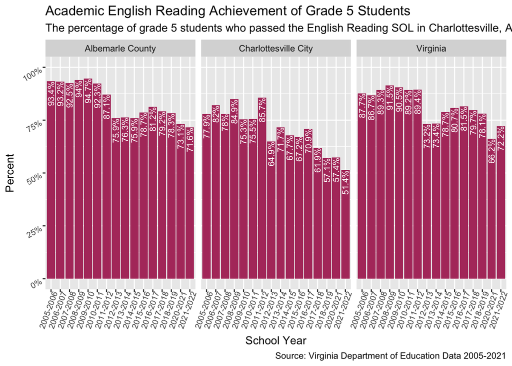

### English SOL Pass Rate-Grade 8

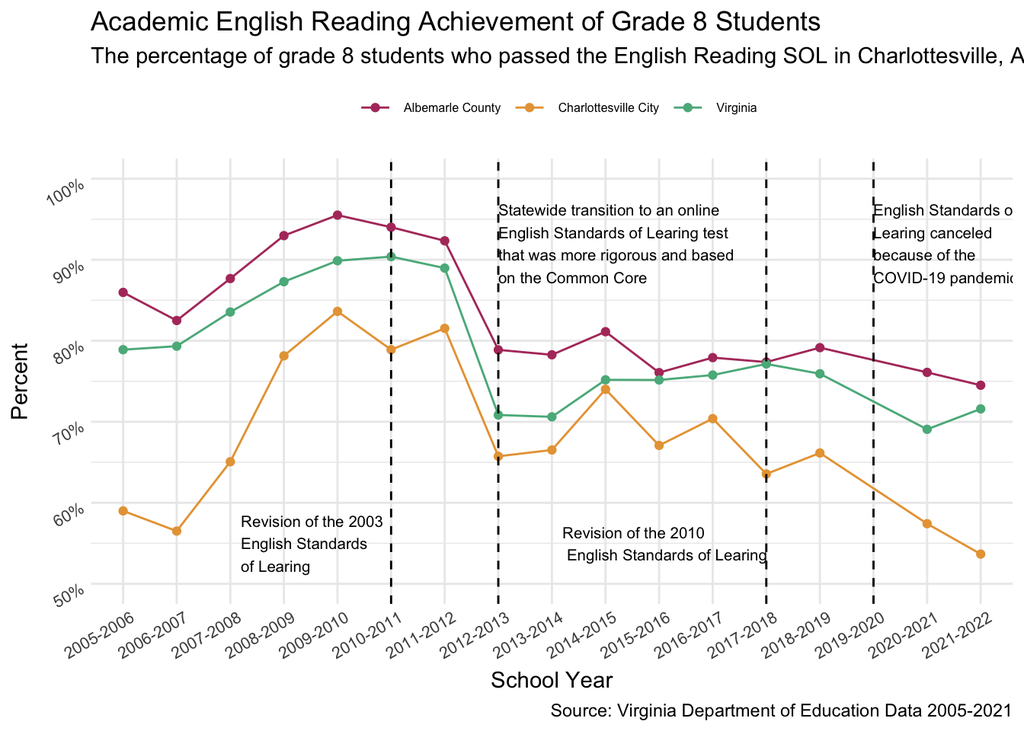

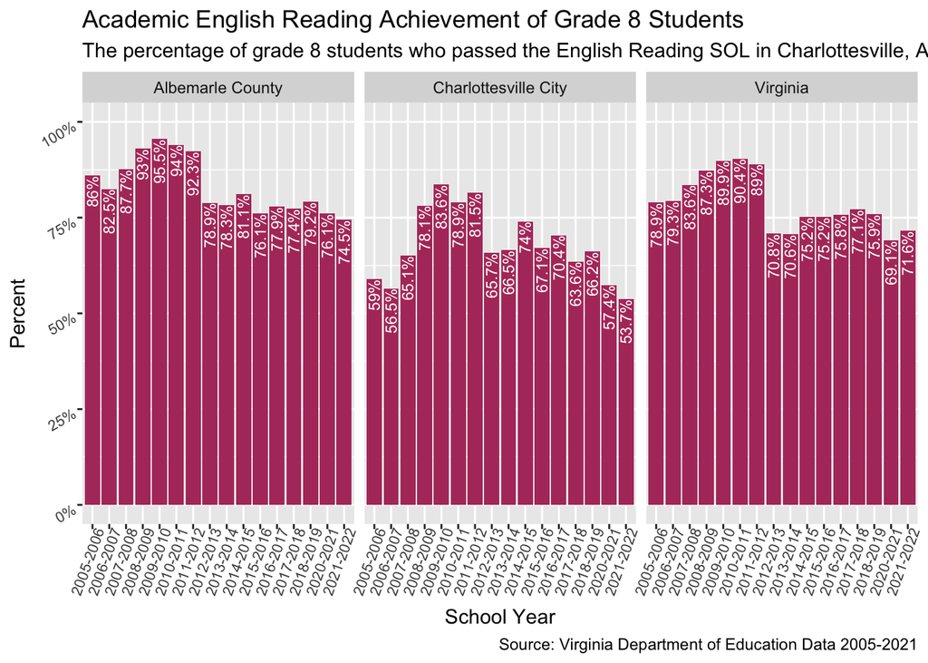

### About

“Education, then, beyond all other divides of human origin, is a great equalizer of conditions of men—the balance wheel of the social machinery.”  
- Horace Mann

This data examines Standards of Learning (SOL) test data specific to Grade 3, 5, and 8 students to offer a comparative outlook on pass percentages at the scale of the county - Charlottesville and Albemarle, and the state of Virginia.

- *Why is this important:* The English Reading SOL evaluates whether students have met the Board of Education’s learning goals in English. For students, these standards outline the goals of the curriculum taught at each grade level and in each subject and promote career and college readiness. Virginia schools use student pass rates on the SOLs to determine a school’s accreditation status. The SOLs are higher stakes for the schools evaluated on their ability to educate.
- *Further Consideration:* A lack of reading proficiency has lasting impacts on student academic success, degree attainment, and future earnings. Studies have revealed that minorities, including economically disadvantaged, disabled, Black, and Hispanic students score disproportionately lower than their peers on the English Reading SOL in Virginia. These trends have only greatened after the pandemic. A majority of these gaps stem from a lack of opportunities. Thirty percent of all students enrolled in Charlottesville public schools are Black, yet white children are four times as likely to be in gifted programs. Trinity, a student enrolled in a predominantly black school, explains how she was denied when she tried to enroll in higher-level courses while her peer, Zyahnna, who goes to a school close to the University of Virginia in a predominantly white neighborhood, was able to take dozens of college-level course. Not only are the opportunities provided by these schools different, but the school zoning in Charlottesville has remended relatively the same since Jim Crow.[Reading Outcomes and Equity in Virginia](https://virginiaequitycenter.github.io/vaequity-reading/), [‘You Are Still Black’: Charlottesville’s Racial Divide Hinders Students](https://www.nytimes.com/2018/10/16/us/charlottesville-riots-black-students-schools.html)
- *Trends:* There is a significant achievement gap between Charlottesville and Albemarle Country English Standard test scores among 5th and 8th graders but not among 3rd graders. A potential cause for this gap may come from “flight” from public middle schools in Charlottesville to private ones. Charlottesville public school families with resources are more likely to transfer their children to private schools instead of sending them to Walker Upper Elementary (5th-6th grade) or Buford Middle (7th-8th) during middle school years. This behavior follows a national trend but in a more significant way. The change in achievement may relate to the overall population of students changing between elementary and middle school. The Code of Virginia requires a review every seven years of Virginia’s Standards of Learning every seven years. The significant drop in test scores in the 2012-2013 school year may result from the transition of common core requirements, which are significantly more rigorous than the prior requirements. The COVID-19 pandemic is likely responsible for the decrease in SOL passing rates after the 2019-2020 school year. Between school closures, declines in enrollment, fewer retakes, and more flexible “opt-out” policies since the pandemic’s beginning, a decline in passing rates reflects the disruptions in school policies.
- *How we measure this:* This is measured by the percentage of students from each grade passing the English Reading SOL. The test consists of approximately forty to sixty questions, and to pass the assessment, students must receive a minimum score of 400.
- *Who is this data about:* This data includes Walker Upper Elementary School a school in Charlottesville that serves children in 5th and 6th grade. The school just released its 2022-2023 [Walker Art Gallary.](http://charlottesvilleschools.org/walker/walker-art-gallery/)
- *Data Source:* Virginia Department of Education, 2002-2017,https://schoolquality.virginia.gov/download-data.